# Crime Stats Project Data Science Department

```python
#Importing our dataframe and extracting Gauteng

import pandas as pd
import matplotlib.pyplot as plt
import pylab as pyl
import numpy as np

section = pd.read_csv('VOCS2016-2017-SECTION21TO28_F1.csv')
gautengS = section[section.prov == 7 ]

household = pd.read_csv('VOCS2016-2017-HOUSEHOLD_F1.csv')
gautengH = household[household.prov == 7 ]
```

### Number of people suveryed per metro in Gauteng

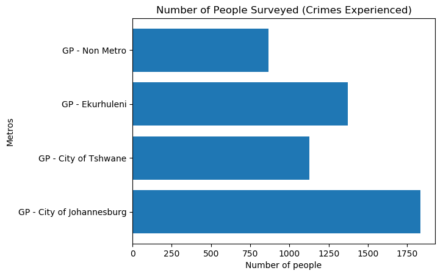

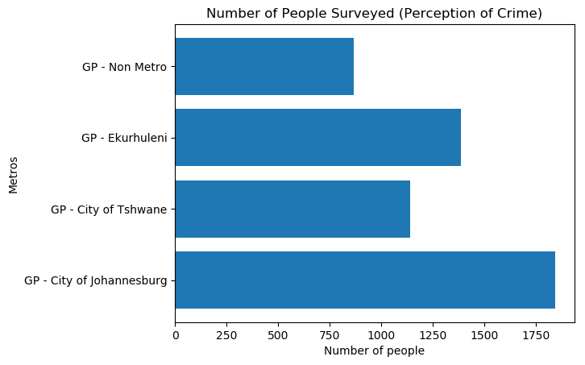

```python
# In this code we are looking at how many people were interviewed from each metro
# This is for section 21 to 28 and household

metrosS = gautengS.groupby('metro_code') .size() .reset_index(name = 'frq')
metrosS

metrosH = gautengH.groupby('metro_code') .size() .reset_index(name = 'frq')
metrosH

labels = ["GP - Non Metro", "GP - Ekurhuleni", "GP - City of Johannesburg", "GP - City of Tshwane"]
ax, bx = plt.subplots()

"""for i, v in enumerate(metros['frq']):
    ax.text(v + 3, i + .25, str(v),fontweight='bold')"""


plt.barh(labels, metrosS['frq'])
plt.title('Number of People Surveyed (Crimes Experienced)')
plt.xlabel('Number of people')
plt.ylabel('Metros')
plt.show()

# This is for Household
plt.barh(labels, metrosH['frq'])
plt.title('Number of People Surveyed (Perception of Crime)')
plt.xlabel('Number of people')
plt.ylabel('Metros')
plt.show()
```

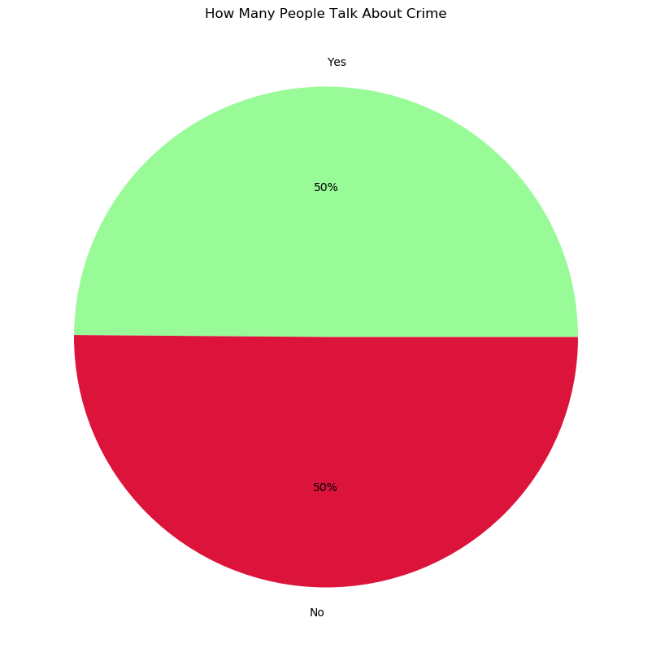

```python
CrimeTopic = gautengH.groupby('Q21topiccrime') .size()
CrimeTopic

CrimeTopic = CrimeTopic[0:2]

labels = ['Yes', 'No', ]
color = ['palegreen','crimson']

#show percentage for each group on the pie chart

plt.pie(CrimeTopic, labels =labels, colors = color, autopct='%1.0f%%')
plt.title('How Many People Talk About Crime')
fig = plt.gcf()
fig.set_size_inches(10,10)
plt.show()
```

### How Many People Are Scared Of Walking During The Day

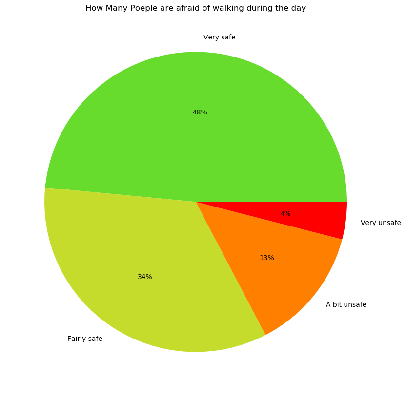

```python
walkingday = gautengH.groupby('Q29WalkDay') .size()
DayWalking = gautengS.groupby('Q21a7WalkDay') .size()

#Here we combined the section 21 to 28 and household data of people who are scared of walking during the day
Household = walkingday[0:4]
Section = DayWalking[0:4]
plot = Household + Section

labels = ['Very safe ', 'Fairly safe', 'A bit unsafe ', 'Very unsafe']
color = ['#67DC2C','#C5DC2C','#FF8000','#FF0000', '#E0E0E0']

plt.pie(plot, labels =labels, autopct='%1.0f%%', colors = color)
plt.title('How Many Poeple are afraid of walking during the day')
fig = plt.gcf()
fig.set_size_inches(10,10)
plt.show()
```

### How Many Peiople Are Scared Of Walking At Night

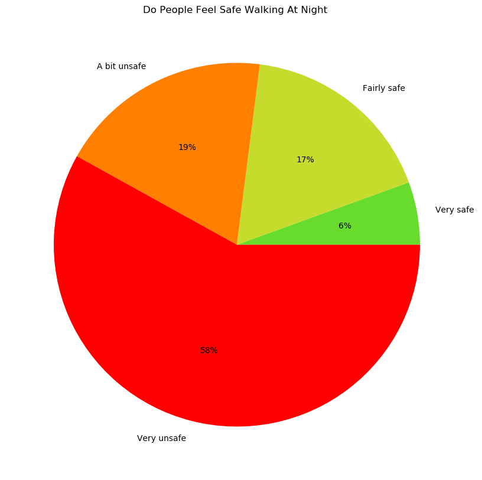

```python
nightWalking = gautengS.groupby('Q21a6WalkDark') .size()
walkingnight = gautengH.groupby('Q28WalkDark') .size()

#combining the two Section 21 to 28 and household
household = walkingnight[0:4]
section = nightWalking[0:4]
plot = household + section

labels = ['Very safe ', 'Fairly safe', 'A bit unsafe', 'Very unsafe']
color = ['#67DC2C','#C5DC2C','#FF8000','#FF0000', '#E0E0E0']

plt.pie(plot, labels =labels, autopct='%1.0f%%', colors = color )
plt.title('Do People Feel Safe Walking At Night ')
fig = plt.gcf()
fig.set_size_inches(10,10)
plt.show()
```

# Protection

How many people in gauteng are concerned about protecting themselves? How do they feel after getting the protection? Can we help them feel more secure?

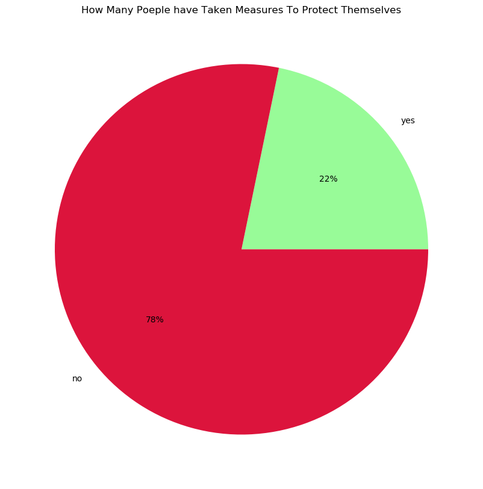

```python
protection = gautengH[['Q321Home','Q322Vehicle', 'Q323Weapons', 'Q324PrivSecur', 'Q325SelfHelp', 'Q326Other']]

yes = protection[protection == 1] .count() .sum()
no  = protection[protection == 2] .count() .sum()
uns = protection[protection == 9] .count() .sum()

df = yes, no
labels = ['yes', 'no']
color = ['palegreen','crimson']

plt.pie(df, labels =labels, autopct='%1.0f%%', colors = color)
plt.title('How Many Poeple have Taken Measures To Protect Themselves')
fig = plt.gcf()
fig.set_size_inches(10,10)
plt.show()
```

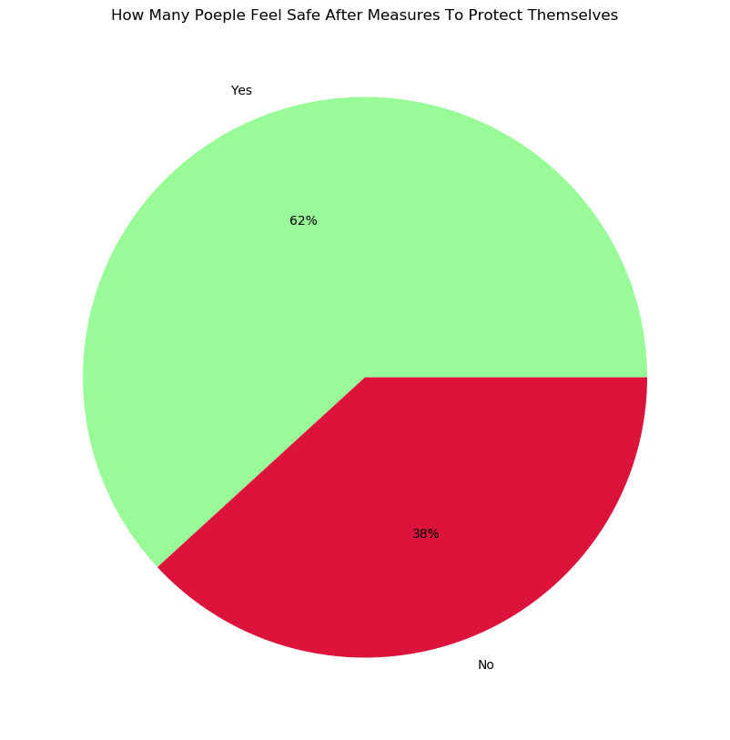

```python
feelsafer = gautengH.groupby('Q33FeelSafer') .size()
feelsafer = feelsafer[0:2]

labels = ['Yes', 'No']
color = ['palegreen','crimson']

plt.pie(feelsafer, labels =labels, autopct='%1.0f%%', colors = color)
plt.title('How Many Poeple Feel Safe After Measures To Protect Themselves')
fig = plt.gcf()
fig.set_size_inches(10,10)
plt.show()
```

# Change in Life style

Here we are trying to figure out how many people have changed their behaviour and routes because they are afraid of crime. The app could help them feel more secure and allow them the freedom to behave and travell freely.

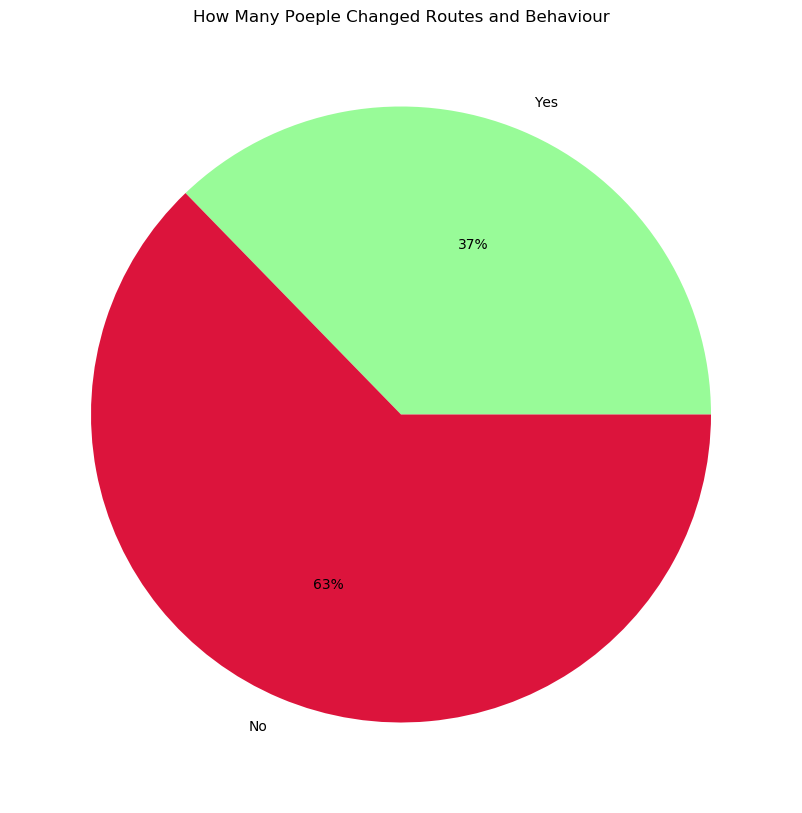

```python
#here ae are analysing the change of routes and behaviour after experiencing a crime or being afraid of a crime
changeofbehaviour = gautengH[['Q1119Changed', 'Q1717Changebehaviour']]
avoidroute = gautengH[['Q11204Avoid']]
Routes = gautengS[['Q21a93ChangRoute']]

# Selecting a count of all the yes and No responses for each colimn
yes = changeofbehaviour[changeofbehaviour == 1] .count() .sum()
no  = changeofbehaviour[changeofbehaviour == 2] .count() .sum()
yes1 = avoidroute[avoidroute == 1] .count() .sum()
no1  = avoidroute[avoidroute == 2] .count() .sum()
yes2 = Routes[Routes == 1] .count() .sum()
no2 = Routes[Routes == 2] .count() .sum()

#Adding all the yes responses and all the no responses
yes = yes + yes1 + yes2
no = no + no1 + no2
plot = yes, no

labels = ['Yes', 'No']
color = ['palegreen','crimson']

# Ploting it into a pie chart
plt.pie(plot, labels =labels, autopct='%1.0f%%', colors = color)
plt.title('How Many Poeple Changed Routes and Behaviour')
fig = plt.gcf()
fig.set_size_inches(10,10)
plt.show()
```

# Avoiding certain places

These people who decided to change avoid certain places, so that they are safe.

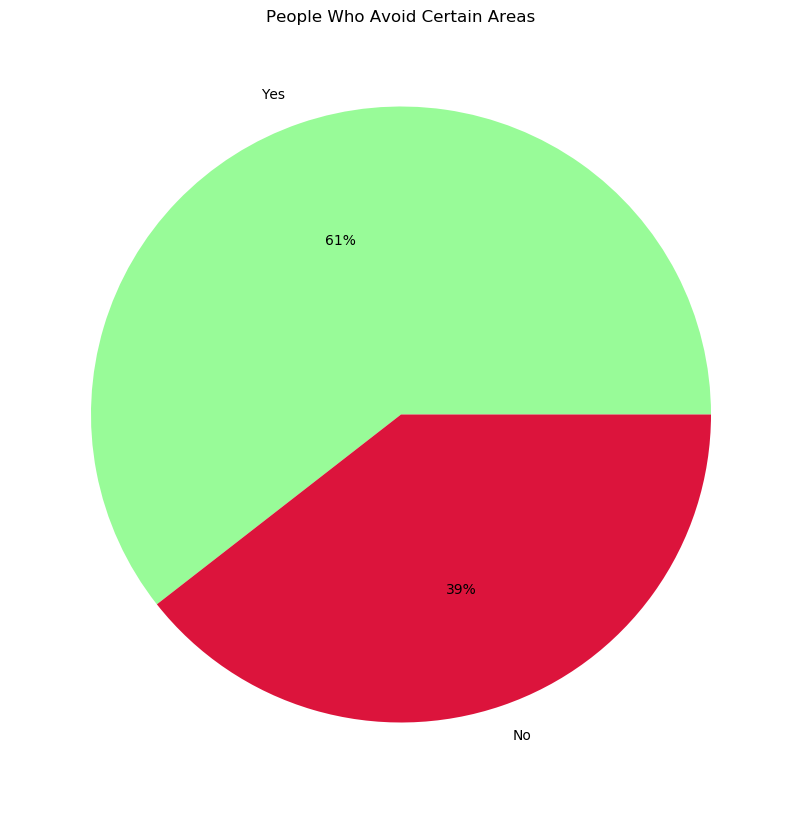

```python
avoid = gautengS.groupby('Q21a94AvoidAreas') .size()
avoid = avoid[0:2]

labels = ['Yes ', 'No']
color = ['palegreen','crimson']
#remove unspecified

plt.pie(avoid, labels =labels, autopct='%1.0f%%', colors = color )
plt.title('People Who Avoid Certain Areas')
fig = plt.gcf()
fig.set_size_inches(10,10)
plt.show()
```

# Police

Here we will look at how much people trust the police, how reliable they think they are and how satisfied they were with reporting a crime.

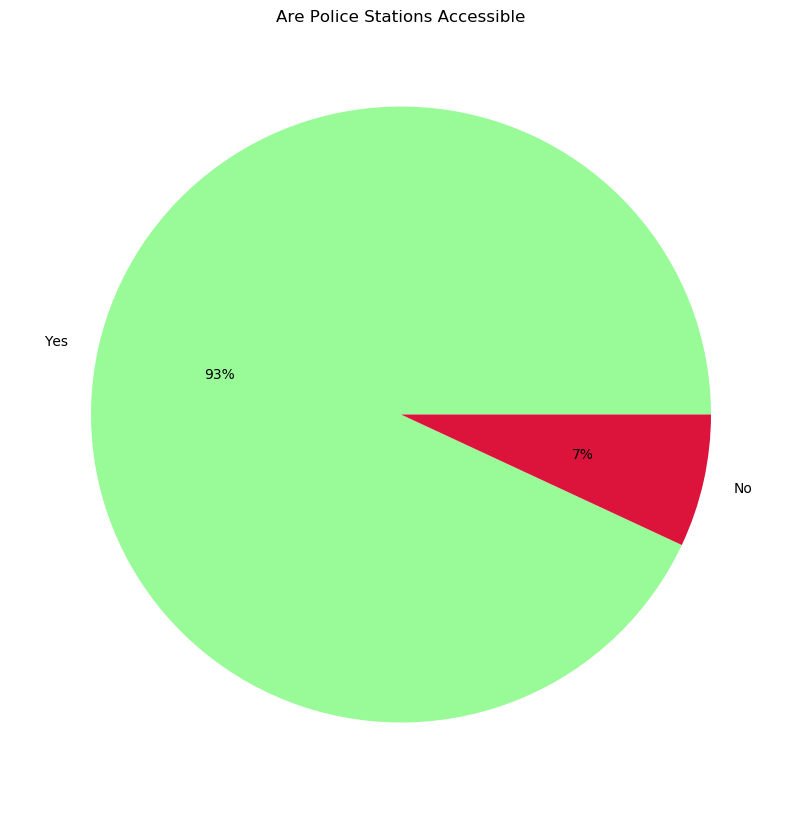

```python
police = gautengH[['Q372Police']]
police

plot = police.groupby('Q372Police') .size()
plot = plot[0:2]


labels = ['Yes', 'No']
color = ['palegreen','crimson']

plt.pie(plot, labels =labels, autopct='%1.0f%%', colors = color)
plt.title('Are Police Stations Accessible')
fig = plt.gcf()
fig.set_size_inches(10,10)
plt.show()
```

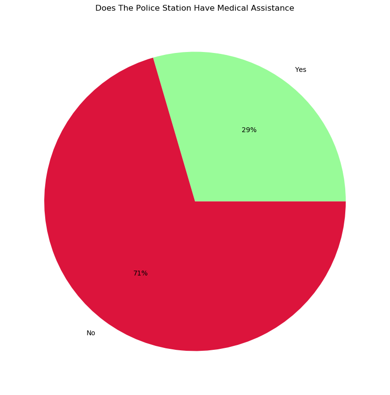

```python
police = gautengH[['Q421Police']]
police

plot = police.groupby('Q421Police') .size()
plot = plot[0:2]


labels = ['Yes', 'No']
color = ['palegreen','crimson']

plt.pie(plot, labels =labels, autopct='%1.0f%%', colors = color)
plt.title('Does The Police Station Have Medical Assistance')
fig = plt.gcf()
fig.set_size_inches(10,10)
plt.show()
```

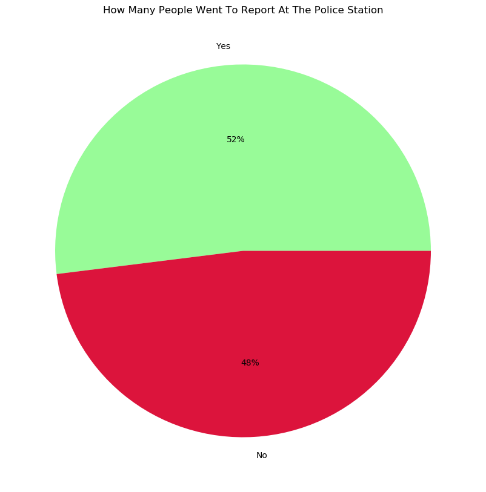

```python
reporting = gautengH[['Q114Report', 'Q127Report', 'Q1313Report', 'Q16a5Report', 'Q175Report','Q194Report','Q204Report' ]]
yes = reporting[reporting == 1] .count() .sum()
no  = reporting[reporting == 2] .count() .sum()
plot = yes, no

labels = ['Yes', 'No']
color = ['palegreen','crimson']

plt.pie(plot, labels =labels, autopct='%1.0f%%', colors = color)
plt.title('How Many People Went To Report At The Police Station')
fig = plt.gcf()
fig.set_size_inches(10,10)
plt.show()
```

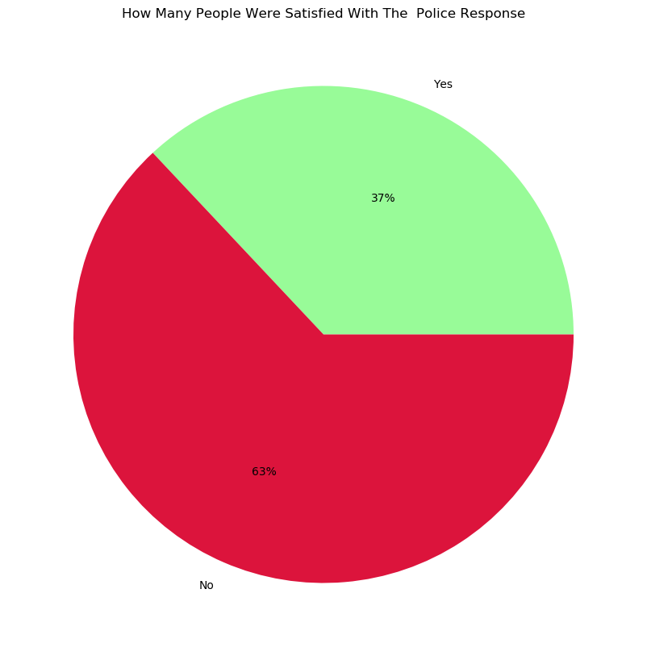

```python
satisfiedwithpolice = gautengH[['Q116Satisfied', 'Q129Satisfied', 'Q1315Satisfied', 'Q16a7Satisfied', 'Q177Satisfied', 'Q196Satisfied', 'Q206Satisfied']]
satisfiedwithpolice

yes = satisfiedwithpolice[satisfiedwithpolice == 1] .count() .sum()
no  = satisfiedwithpolice[satisfiedwithpolice == 2] .count() .sum()
plot = yes, no

labels = ['Yes', 'No']
color = ['palegreen','crimson']

plt.pie(plot, labels =labels, autopct='%1.0f%%', colors = color)
plt.title('How Many People Were Satisfied With The  Police Response')
fig = plt.gcf()
fig.set_size_inches(10,10)
plt.show()
```

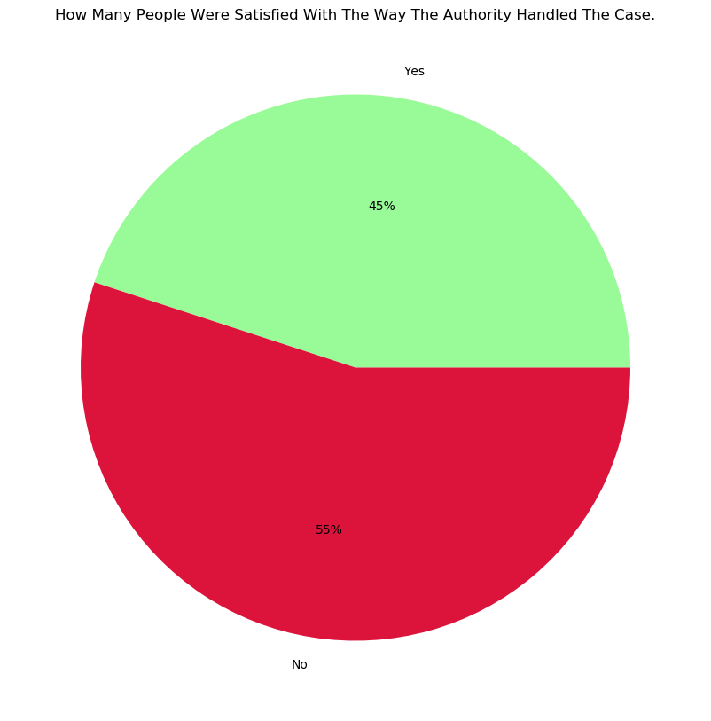

```python
satiswithhandling = gautengH[['Q12131Police','Q16a18Police', 'Q13191Police', 'Q11101Police','Q1711Police', 'Q1910Police', 'Q2010Police' ]]
satiswithhandling

yes = satiswithhandling[satiswithhandling == 1] .count() .sum()
no  = satiswithhandling[satiswithhandling == 2] .count() .sum()
plot = yes, no

labels = ['Yes', 'No']
color = ['palegreen','crimson']

plt.pie(plot, labels =labels, autopct='%1.0f%%', colors = color)
plt.title('How Many People Were Satisfied With The Way The Authority Handled The Case.')
fig = plt.gcf()
fig.set_size_inches(10,10)
plt.show()
```

# The Emergency Call

Who is the first person you call when you are having an emergency or in danger?

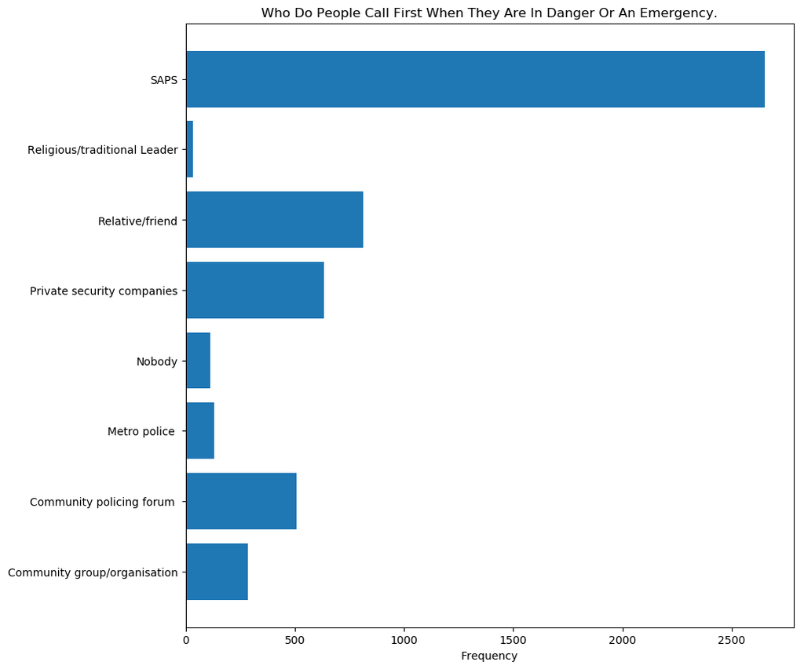

```python
firstcall = gautengH.groupby('Q36Victims') .size() .reset_index(name = 'number')
#we drop index 8 because it's the count of unspecified responses, which we want to ignore
firstcall = firstcall.drop(firstcall.index[8])

x = labels
y = firstcall['number']

labels = ['Nobody', 'Relative/friend', 'Private security companies', 'Community group/organisation',
          'Religious/traditional Leader', 'SAPS', 'Metro police ', 'Community policing forum ']

plt.barh(x,y)
plt.xlabel('Frequency')
plt.title('Who Do People Call First When They Are In Danger Or An Emergency.')
fig = plt.gcf()
fig.set_size_inches(10,10)
plt.show()
```

#### When people are in danger they're more likely to call the South African Police Services (SAPS).

# Crimes

### These are the most feared crimes.

```python
feared_codes = ["Q2221Murder", "Q2222StrRob", "Q2223HomeRob", "Q2224BussRob", "Q2225Hijack", "Q2226Assault", "Q2227SexAssult",
            "Q2228ChildAbuse", "Q2229Political", "Q22210Vigilante", "Q22211BagSnatch",
            "Q22212Bicycle", "Q22213Car", "Q22214Burglary", "Q22215Crop", "Q22216Livestock", "Q22217WhiteCollar", "Q22218damage",
            "Q22219IDtheft", "Q22220HumanTrafficking", "Q22221DrugTrafficking", "Q22222HateCrime", "Q22223Other"]

occur_codes = ["Q2211Murder", "Q2212StrRob", "Q2213HomeRob", "Q2214BussRob", "Q2215Hijack", "Q2216Assault", "Q2217SexAssult",
            "Q2218ChildAbuse", "Q2219Political", "Q22110Vigilante", "Q22111BagSnatch",
            "Q22112Bicycle", "Q22113Car", "Q22114Burglary", "Q22115Crop", "Q22116Livestock", "Q22117WhiteCollar", "Q22118damage",
            "Q22119IDtheft", "Q22120HumanTrafficking", "Q22121DrugTrafficking", "Q22122HateCrime", "Q22123Other"]

# this list contains the labels of the crimes
crime_labels = ["Murder", "Street Robbery", "Home Roberry", "Business Robbery","Vehicle Hijacking", "Assault", "Sexual Assault",
          "Child Abuse", "Political Violence", "Vigilantism", "Bag Snatching", "Bicycle Theft", "Vehicle Theft", "House Breaking",
          "Crop Theft", "Livestock Theft", "White Collar", "Damage", "Id theft", "Human Trafficking", "Drug Trafficking",
          "Hate Crime", "Other Crime"]
```

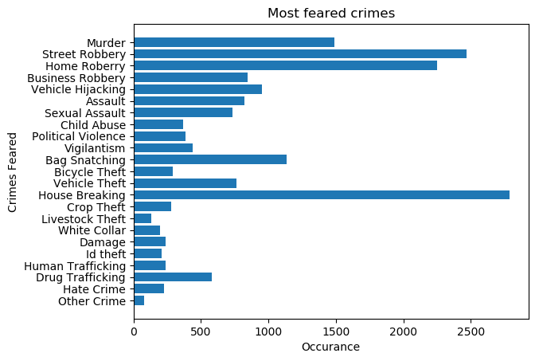

```python
def freqCount(region, topic_code, response_code):
    return region.groupby(topic_code).size().reset_index(name = 'frequency')['frequency'][response_code]

def multiFreqCount(region, occur_codes, response):
    crime_count = []
    for topic in occur_codes:
        crime_count.append(freqCount(gautengH, topic, response))

    return crime_count

plt.rcdefaults()
fig, fc = plt.subplots()

# Example data
y_pos = np.arange(len(crime_labels))

fc.barh(y_pos, multiFreqCount(gautengH, feared_codes, 0))
fc.set_yticks(y_pos)
fc.set_yticklabels(crime_labels)
fc.invert_yaxis()  # labels read top-to-bottom
fc.set_xlabel('Occurance')
fc.set_ylabel('Crimes Feared')
fc.set_title('Most feared crimes')
plt.show()
```

### These are the crimes that people think occur most in their area.

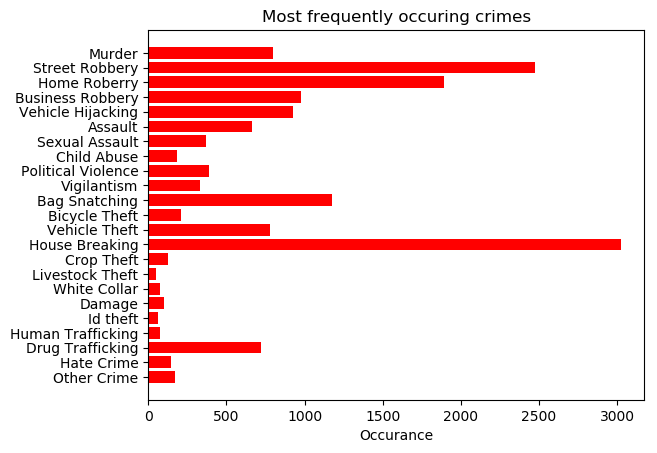

```python
plt.rcdefaults()
fig, fc = plt.subplots()

# Example data
y_pos = np.arange(len(crime_labels))

fc.barh(y_pos, multiFreqCount(gautengH, occur_codes, 0), color='red')
fc.set_yticks(y_pos)
fc.set_yticklabels(crime_labels)
fc.invert_yaxis()  # labels read top-to-bottom
fc.set_xlabel('Occurance')
fc.set_title('Most frequently occuring crimes')
plt.show()
```

#### The perception is that Housebreaking is the most frequently occuring crime, followed by Street Robbery (Mugging), Home Robbery and Bag Snatching.

NB:

- Housebreaking is when a burglary occurs when there is no one in the house.
- Home robbery is when there are people present in the house while the crime occurs.

### Crime that were actually experience in the past 5 years.

```python
crimes  = gautengS[['Q21b1aPersProp', 'Q21b11CarHijack', 'Q21b11cRob', 'Q21b1dSexual', 'Q21b1eAssault', 'Q21b1hOther']]
```

```python
# Here I am grouping each crime to figure out how many people reported yes to experiencing each crime

persprop = crimes.groupby('Q21b1aPersProp') . size()
CarHij = crimes.groupby('Q21b11CarHijack') .size()
Rob = crimes.groupby('Q21b11cRob') .size()
SexualOff = crimes.groupby('Q21b1dSexual') .size()
Assualt = crimes.groupby('Q21b1eAssault') .size()
Other = crimes.groupby('Q21b1hOther') .size()
```

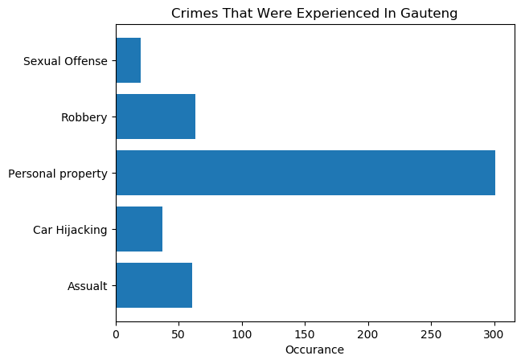

```python
#These are all the "YES" cases
labels = ['Personal property','Car Hijacking','Sexual Offense','Assualt', 'Robbery']
counts = [persprop[1],CarHij[1],SexualOff[1],Assualt[1], Rob[1]]

plt.barh(labels, counts)
plt.xlabel('Occurance')
plt.title("Crimes That Were Experienced In Gauteng")
plt.show()
```